# Reproducible Research - Peer-graded Assignment: Course Project 1

pduchesne

25 February 2017

### Load libraries

Load DLPYR, RColorBrewer & Hmisc libraries

```r
library(Hmisc)
library(dplyr)
library(RColorBrewer)
```

Load source file and extract

```r
# verify if activity.zip exists in the working directory, if not download file.
if(!file.exists("./activity.zip")){
        fileUrl <- "https://d396qusza40orc.cloudfront.net/repdata%2Fdata%2Factivity.zip"
        download.file(fileUrl, destfile="./activity.zip")
}

# extract file if "/course project 1/activity" directory is not present
if(!file.exists("./activity")){
        unzip("./activity.zip", files = NULL, list = FALSE, overwrite = TRUE,
              junkpaths = FALSE, exdir = "./activity", unzip = "internal",
              setTimes = FALSE)
}
```

## What is mean total number of steps taken per day?

Load file into data frame.

```r
df_activity <- read.csv("./activity/activity.csv", na.strings="NA", stringsAsFactors=FALSE)
df_activity$date<-as.Date.character(df_activity$date,format = "%Y-%m-%d")
```

1. Calculate the total number of steps taken per day.

```r
df_daily <- aggregate(df_activity$steps, by=list(df_activity$date), FUN=sum, na.rm=TRUE)
names(df_daily)<-c("date","steps")
```

2. Make a histogram of the total number of steps taken each day ## Histogram of the total number of steps taken each day

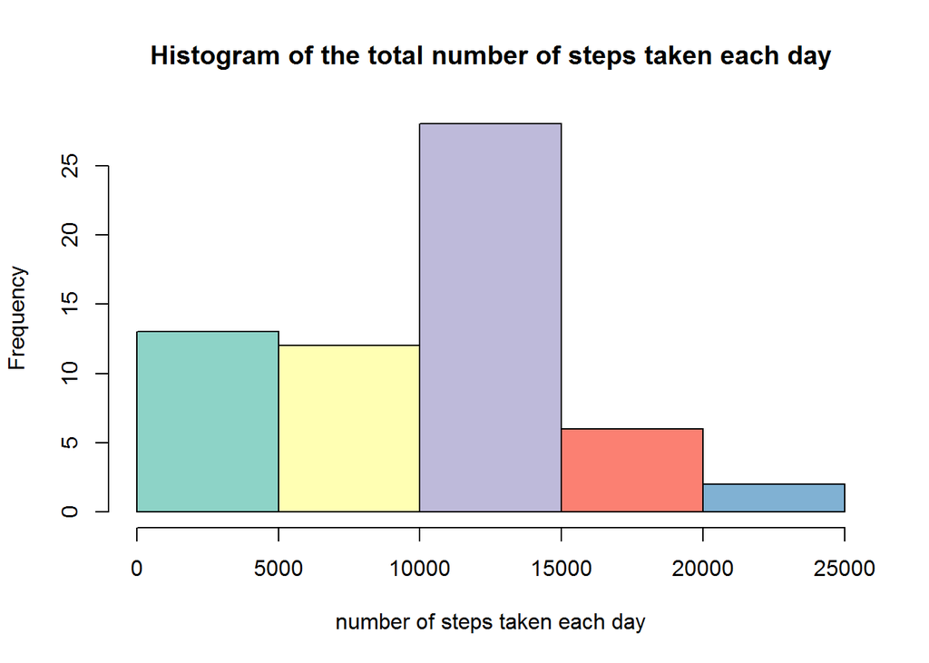

```r
hist(df_daily$steps,col=brewer.pal(5,"Set3"),
main="Histogram of the total number of steps taken each day",
xlab="number of steps taken each day"
)
```

3. Calculate and report the mean and median of the total number of steps taken per day

```r
df_M_M <- data.frame(Mean = mean(df_daily$steps, na.rm=TRUE), Median = median(df_daily$steps, na.rm=TRUE))
knitr::kable(df_M_M)
```

| Mean | Median |
| --- | --- |
| 9354.23 | 10395 |

## What is the average daily activity pattern?

1. Make a time series plot of the 5-minute interval (x-axis) and the average number of steps taken, averaged across all days (y-axis)

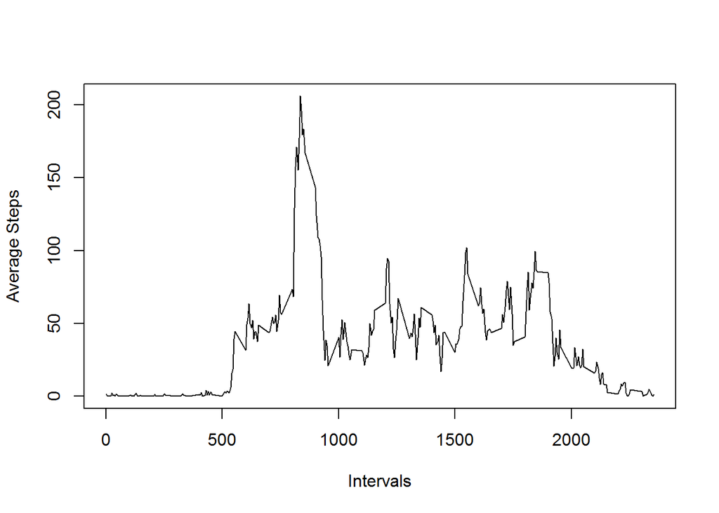

```r
df_interval_avg <- df_activity %>% group_by(interval) %>% summarize(mean_steps = mean(steps, na.rm = TRUE))
plot(df_interval_avg$interval,df_interval_avg$mean_steps, type="l", xlab="Intervals",ylab = "Average Steps")
```

2. Which 5-minute interval, on average across all the days in the dataset, contains the maximum number of steps?

```r
mx <-max(df_interval_avg$mean_steps)
five_minute_interval <- df_interval_avg %>% select(interval) %>% filter(df_interval_avg$mean_steps == mx)
knitr::kable(five_minute_interval)
```

## interval

```
  835
```

## Imputing missing values

1. The total number of rows with NA:

```r
df_missing<-sum(is.na(df_activity$steps))
names(df_missing)<-"Total : "
knitr::kable(df_missing)
```

| Total : | 2304 |
| --- | --- |

2. Strategy for filling in all of the missing values in the dataset: use **Hmisc** package
3. Create a new dataset that is equal to the original dataset but with the missing data filled in.

```r
df_activity_wo_na <- df_activity
df_activity_wo_na$steps <- with(df_activity, impute(steps, mean))
```

4. Make a histogram of the total number of steps taken each day and Calculate and report the mean and median total number of steps taken per day.

## Histogram of the total number of steps taken each day (without NA)

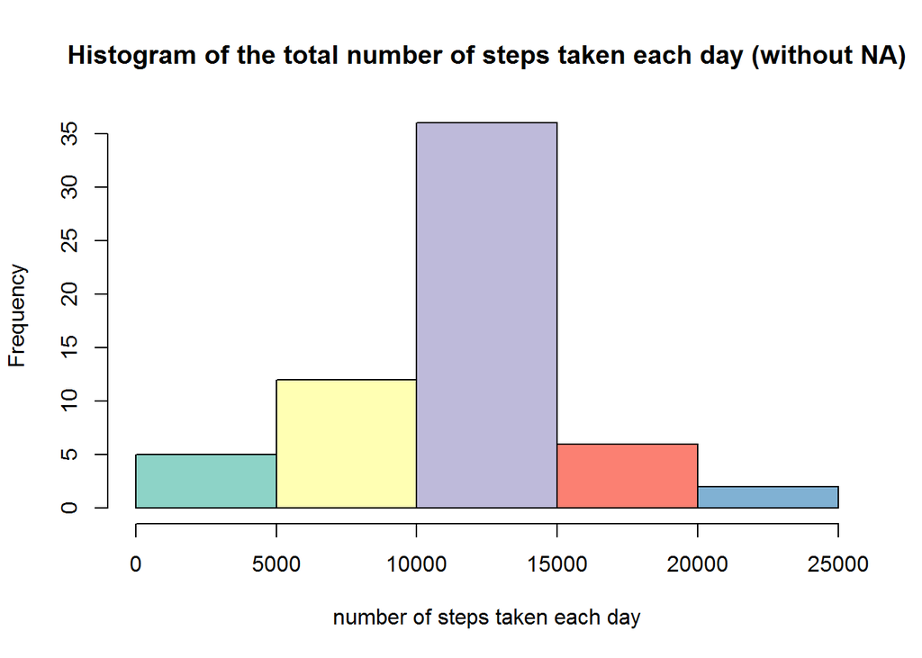

```r
df_daily_wo_na <- aggregate(df_activity_wo_na$steps, by=list(df_activity_wo_na$date), FUN=sum, na.rm=TRUE)
names(df_daily_wo_na)<-c("date","steps")

hist(df_daily_wo_na$steps,col=brewer.pal(5,"Set3"),
main="Histogram of the total number of steps taken each day (without NA)",
xlab="number of steps taken each day")
```

and calculate and report the mean and median of the total number of steps taken per day

```r
df_M_M_wo_na <- data.frame(Mean = mean(df_daily_wo_na$steps, na.rm=TRUE), Median = median(df_daily_wo_na$steps, na.rm=TRUE))
knitr::kable(df_M_M_wo_na)
```

| Mean | Median |
| --- | --- |
| 10766.19 | 10766.19 |

## Are there differences in activity patterns between weekdays and weekends?

#### Create a new factor variable in the dataset with two levels - “weekday” and “weekend”

```r
df_activity_wo_na$day_type[weekdays(df_activity_wo_na$date, abbreviate = TRUE) %in% c("Sat","Sun")] <- "Weekend"
df_activity_wo_na$day_type[is.na(df_activity_wo_na$day_type)]<-"Weekday"
df_activity_wo_na$day_type<- as.factor(df_activity_wo_na$day_type)

df_interval_avg_wo_na <- df_activity_wo_na %>% group_by(interval,day_type) %>% summarize(mean_steps = mean(steps, na.rm = TRUE))
```

#### Make a panel plot containing a time series plot of the 5-minute interval (x-axis) and the average number of steps taken, averaged across all weekday days or weekend days (y-axis).

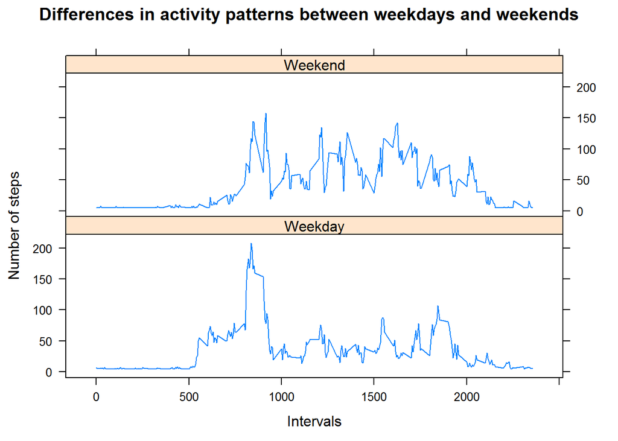

```r
xyplot(df_interval_avg_wo_na$mean_steps ~ df_interval_avg_wo_na$interval|df_interval_avg_wo_na$day_type,
            main="Differences in activity patterns between weekdays and weekends",
            xlab="Intervals",ylab="Number of steps",type = "l",
            layout=c(1,2))
```